# Analyse Socio-Économique des Départements Français

Rapport

Auteur·rice

Stave Icnel Dany OSIAS

Date de publication

5 décembre 2025

1. Chargeons les données `départements` et faisons un résumé descriptif standard, tout en affichant les premières observations:

Structure des données

| Variable | Type | Valeurs |
| --- | --- | --- |
| TXCR | num | 12.19 0.89 -2.63 10 7.82 … |
| ETRA | num | 0.095 0.035 0.031 0.046 0.037 0.091 0.039 0.056 0.055 0.057 … |
| URBR | num | 0.339 0.358 0.464 0.19 0.294 0.945 0.281 0.324 0 0.424 … |
| JEUN | num | 0.285 0.289 0.227 0.235 0.25 0.21 0.252 0.292 0.215 0.27 … |
| AGE | num | 0.133 0.143 0.204 0.19 0.173 0.217 0.184 0.138 0.228 0.155 … |
| CHOM | num | 0.07 0.133 0.135 0.123 0.089 0.119 0.105 0.144 0.12 0.113 … |
| AGRI | num | 0.045 0.049 0.086 0.065 0.072 0.012 0.085 0.065 0.09 0.068 … |
| ARTI | num | 0.084 0.07 0.095 0.127 0.117 0.124 0.106 0.069 0.103 0.067 … |
| CADR | num | 0.088 0.071 0.07 0.09 0.078 0.127 0.073 0.065 0.073 0.067 … |
| EMPL | num | 0.24 0.24 0.262 0.261 0.302 0.316 0.224 0.24 0.261 0.227 … |
| OUVR | num | 0.347 0.4 0.311 0.256 0.23 0.227 0.329 0.386 0.298 0.401 … |
| PROF | num | 0.195 0.171 0.176 0.2 0.201 0.194 0.184 0.176 0.175 0.17 … |
| FISC | num | 2772 2854 3160 4033 3365 … |
| CRIM | num | 38.7 52.2 39 57.7 49.2 … |
| FE90 | num | 52.3 56.9 42.7 52.3 53.5 50 48.4 55.6 44.1 51.9 … |

`````

Résumé statistique de TXCR

| Statistique | Valeur |
| --- | --- |
| Min. | -5.73 |
| 1st Qu. | 0.33 |
| Median | 2.74 |
| Mean | 3.76 |
| 3rd Qu. | 6.51 |
| Max. | 21.87 |

Résumé statistique de ETRA

| Statistique | Valeur |
| --- | --- |
| Min. | 0.01 |
| 1st Qu. | 0.03 |
| Median | 0.05 |
| Mean | 0.05 |
| 3rd Qu. | 0.07 |
| Max. | 0.19 |

Résumé statistique de URBR

| Statistique | Valeur |
| --- | --- |
| Min. | 0.00 |
| 1st Qu. | 0.27 |
| Median | 0.40 |
| Mean | 0.44 |
| 3rd Qu. | 0.56 |
| Max. | 1.00 |

Résumé statistique de JEUN

| Statistique | Valeur |
| --- | --- |
| Min. | 0.19 |
| 1st Qu. | 0.24 |
| Median | 0.26 |
| Mean | 0.26 |
| 3rd Qu. | 0.28 |
| Max. | 0.31 |

Résumé statistique de AGE

| Statistique | Valeur |
| --- | --- |
| Min. | 0.09 |
| 1st Qu. | 0.13 |
| Median | 0.16 |
| Mean | 0.16 |
| 3rd Qu. | 0.19 |
| Max. | 0.25 |

Résumé statistique de CHOM

| Statistique | Valeur |
| --- | --- |
| Min. | 0.06 |
| 1st Qu. | 0.09 |
| Median | 0.11 |
| Mean | 0.11 |
| 3rd Qu. | 0.12 |
| Max. | 0.17 |

Résumé statistique de AGRI

| Statistique | Valeur |
| --- | --- |
| Min. | 0.00 |
| 1st Qu. | 0.03 |
| Median | 0.06 |
| Mean | 0.07 |
| 3rd Qu. | 0.09 |
| Max. | 0.22 |

Résumé statistique de ARTI

| Statistique | Valeur |
| --- | --- |
| Min. | 0.05 |
| 1st Qu. | 0.07 |
| Median | 0.08 |
| Mean | 0.09 |
| 3rd Qu. | 0.10 |
| Max. | 0.14 |

Résumé statistique de CADR

| Statistique | Valeur |
| --- | --- |
| Min. | 0.05 |
| 1st Qu. | 0.07 |
| Median | 0.08 |
| Mean | 0.09 |
| 3rd Qu. | 0.10 |
| Max. | 0.32 |

Résumé statistique de EMPL

| Statistique | Valeur |
| --- | --- |
| Min. | 0.21 |
| 1st Qu. | 0.24 |
| Median | 0.25 |
| Mean | 0.26 |
| 3rd Qu. | 0.27 |
| Max. | 0.33 |

Résumé statistique de OUVR

| Statistique | Valeur |
| --- | --- |
| Min. | 0.13 |
| 1st Qu. | 0.27 |
| Median | 0.31 |
| Mean | 0.31 |
| 3rd Qu. | 0.36 |
| Max. | 0.41 |

Résumé statistique de PROF

| Statistique | Valeur |
| --- | --- |
| Min. | 0.14 |
| 1st Qu. | 0.17 |
| Median | 0.18 |
| Mean | 0.19 |
| 3rd Qu. | 0.20 |
| Max. | 0.25 |

Résumé statistique de FISC

| Statistique | Valeur |
| --- | --- |
| Min. | 2216.90 |
| 1st Qu. | 2768.80 |
| Median | 2978.00 |
| Mean | 3110.26 |
| 3rd Qu. | 3354.30 |
| Max. | 5029.70 |

Résumé statistique de CRIM

| Statistique | Valeur |
| --- | --- |
| Min. | 24.60 |
| 1st Qu. | 36.75 |
| Median | 46.20 |
| Mean | 52.06 |
| 3rd Qu. | 62.25 |
| Max. | 139.90 |

Résumé statistique de FE90

| Statistique | Valeur |
| --- | --- |
| Min. | 39.50 |
| 1st Qu. | 47.70 |
| Median | 51.40 |
| Mean | 50.70 |
| 3rd Qu. | 53.75 |
| Max. | 64.40 |

Aperçu des données `départements`

| TXCR | ETRA | URBR | JEUN | AGE | CHOM | AGRI | ARTI | CADR | EMPL | OUVR | PROF | FISC | CRIM | FE90 |
| --- | --- | --- | --- | --- | --- | --- | --- | --- | --- | --- | --- | --- | --- | --- |
| 12.19 | 0.10 | 0.34 | 0.28 | 0.13 | 0.07 | 0.04 | 0.08 | 0.09 | 0.24 | 0.35 | 0.20 | 2772.3 | 38.7 | 52.3 |
| 0.89 | 0.04 | 0.36 | 0.29 | 0.14 | 0.13 | 0.05 | 0.07 | 0.07 | 0.24 | 0.40 | 0.17 | 2854.4 | 52.2 | 56.9 |
| -2.63 | 0.03 | 0.46 | 0.23 | 0.20 | 0.14 | 0.09 | 0.10 | 0.07 | 0.26 | 0.31 | 0.18 | 3159.6 | 39.0 | 42.7 |
| 10.00 | 0.05 | 0.19 | 0.23 | 0.19 | 0.12 | 0.06 | 0.13 | 0.09 | 0.26 | 0.26 | 0.20 | 4033.1 | 57.7 | 52.3 |
| 7.82 | 0.04 | 0.29 | 0.25 | 0.17 | 0.09 | 0.07 | 0.12 | 0.08 | 0.30 | 0.23 | 0.20 | 3364.9 | 49.2 | 53.5 |
| 10.56 | 0.09 | 0.94 | 0.21 | 0.22 | 0.12 | 0.01 | 0.12 | 0.13 | 0.32 | 0.23 | 0.19 | 4335.4 | 123.6 | 50.0 |

- Notre jeu de données comprend 95 observations pour 15 variables toutes quantitatives. Ceci nous suggère déjà que la méthode d’analyse appropriée pour ce jeu de données est l’Analyse des Composantes Principales (ACP).
- Mais, bien avant de réaliser l’ACP, remarquons d’abord que les variables `FISC`, `CRIM` et `FE90` prennent de très grandes valeurs. Ceci suggère la nécessité d’une standardisation des données.
2. Standardisons nos données:

Aperçu des données `départements` standardisées

| TXCR | ETRA | URBR | JEUN | AGE | CHOM | AGRI | ARTI | CADR | EMPL | OUVR | PROF | FISC | CRIM | FE90 |
| --- | --- | --- | --- | --- | --- | --- | --- | --- | --- | --- | --- | --- | --- | --- |
| 1.7 | 1.3 | -0.4 | 1.0 | -0.8 | -1.7 | -0.5 | -0.1 | -0.1 | -0.7 | 0.7 | 0.3 | -0.6 | -0.6 | 0.3 |
| -0.6 | -0.5 | -0.3 | 1.1 | -0.6 | 0.9 | -0.4 | -0.8 | -0.5 | -0.7 | 1.6 | -0.6 | -0.5 | 0.0 | 1.3 |
| -1.3 | -0.6 | 0.1 | -1.2 | 1.2 | 1.0 | 0.3 | 0.5 | -0.5 | 0.3 | 0.0 | -0.4 | 0.1 | -0.6 | -1.7 |
| 1.3 | -0.2 | -1.1 | -0.9 | 0.8 | 0.5 | -0.1 | 2.1 | -0.1 | 0.2 | -0.9 | 0.5 | 1.7 | 0.3 | 0.3 |
| 0.8 | -0.4 | -0.6 | -0.3 | 0.3 | -0.9 | 0.0 | 1.6 | -0.3 | 1.9 | -1.4 | 0.6 | 0.5 | -0.1 | 0.6 |
| 1.4 | 1.2 | 2.2 | -1.8 | 1.5 | 0.3 | -1.2 | 2.0 | 0.9 | 2.5 | -1.5 | 0.3 | 2.3 | 3.4 | -0.1 |

3. Ajoutons les noms de tous les départements comme indices des lignes.

Notons que dans le jeu de données, le nom du $20^{ème}$ département a été omis alors que les données correspondantes ont été bien enregistrées. On le notera par `Dept20`.

Aperçu des données `départements` avec les noms

|  | TXCR | ETRA | URBR | JEUN | AGE | CHOM | AGRI | ARTI | CADR | EMPL |
| --- | --- | --- | --- | --- | --- | --- | --- | --- | --- | --- |
| Ain | 1.72 | 1.31 | -0.42 | 0.96 | -0.84 | -1.66 | -0.50 | -0.10 | -0.10 | -0.67 |
| Aisne | -0.58 | -0.49 | -0.34 | 1.10 | -0.55 | 0.90 | -0.42 | -0.82 | -0.52 | -0.67 |
| Allier | -1.30 | -0.61 | 0.12 | -1.17 | 1.17 | 0.98 | 0.32 | 0.47 | -0.55 | 0.25 |
| Alpes Haute Provence | 1.27 | -0.16 | -1.06 | -0.87 | 0.77 | 0.50 | -0.10 | 2.11 | -0.05 | 0.21 |
| Hautes Alpes | 0.83 | -0.43 | -0.62 | -0.32 | 0.29 | -0.89 | 0.04 | 1.60 | -0.35 | 1.93 |
| Alpes Maritimes | 1.39 | 1.19 | 2.19 | -1.79 | 1.53 | 0.33 | -1.16 | 1.96 | 0.86 | 2.52 |

4. Analysons les corrélations entre les variables socioéconomiques:

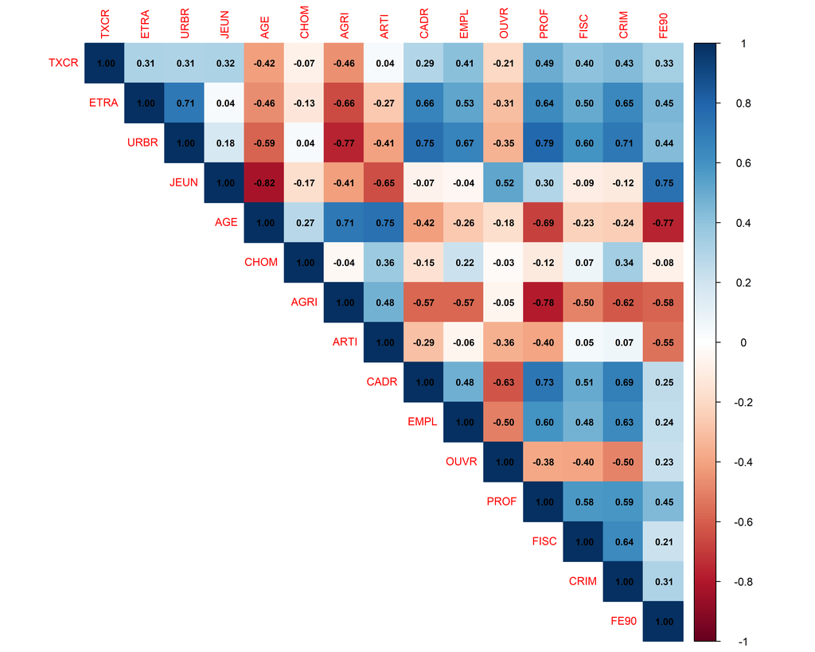

On peut remarquer que certaines variables sont fortement liées et de manière logique:

- Les variables `AGE` et `JEUN` sont fortement corrélées négativement: ce qui est cohérent puisque plus il y a de jeunes, moins il y a de personnes âgées.
- Les variables `URBR` (urbanisation) et `AGRI` (agriculteur) sont aussi fortement corrélées négativement: ce qui est encore logique géographiquement puisqu’en pratique, les agriculteurs ne vivent pas dans les milieux urbains.
- Par ailleurs, les variables`PROF` et `URBR` , tout comme `CADR` et `URBR`sont positivement corrélées: c’est encore logique car dans les zones urbaines, il y a généralement plus de cadres supérieurs et plus de professions intermédiaires.
- Les variables `CRIM` et `URBR` sont aussi fortement corrélées positivement: ce qui suggère logiquement que le taux de criminalité est plus élevé dan les zones urbaines.
- Et pour finir, les variables `AGE` et `FE90` sont fortement corrélées négativement: ce qui suggère logiquement que le taux de fécondité devient plus faible quand la part de personnes âgées augmente.
- A l’inverse, les variables `JEUN` et `FE90` sont, en effet, fortement corrélées positivement car plus il y a de jeunes, plus il y a de naissances et donc, plus le taux de fécondité augmente.
5. Visualisons les nuages de points par paire pour mettre en évidence ces relations:

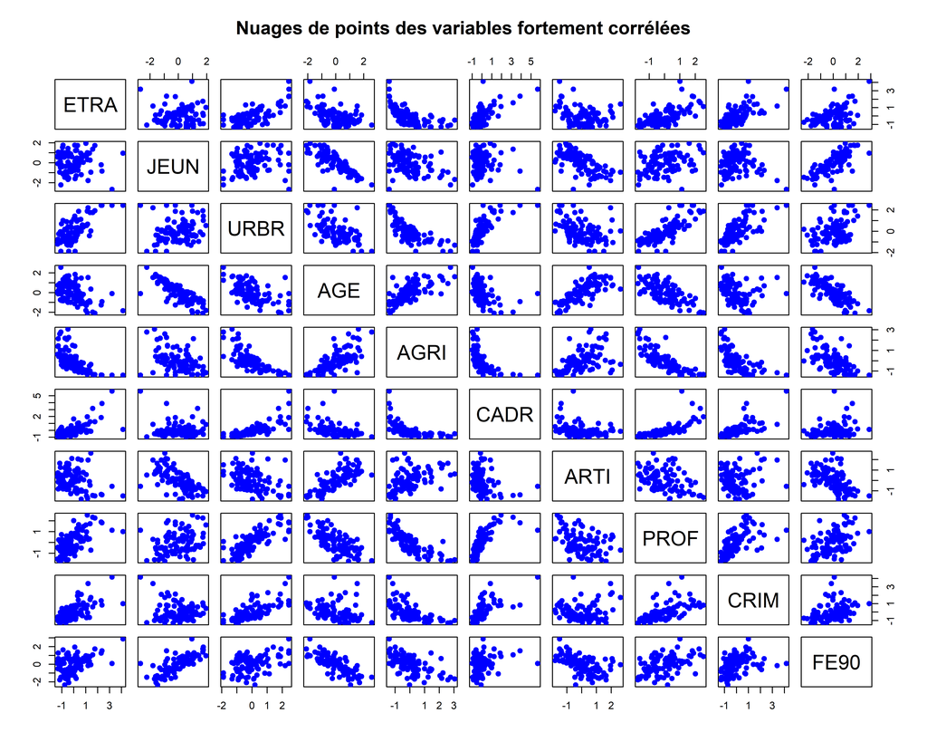

- Les nuages de points confirment, en effet, l’existence de corrélations fortement positives ou fortement négatives entre certaines de nos variables socioéconomiques. Ces relations mettent en évidence des redondances dans l’information contenue dans le jeu de données.
- D’où la nécessité de réaliser une Analyse des Composantes Principales sur notre jeu de données afin de réduire la dimensionalité, de synthétiser l’information et de limiter l’effet de ces corrélations.
6. Réalisons donc une ACP sur notre jeu de données `départements` standardisées:

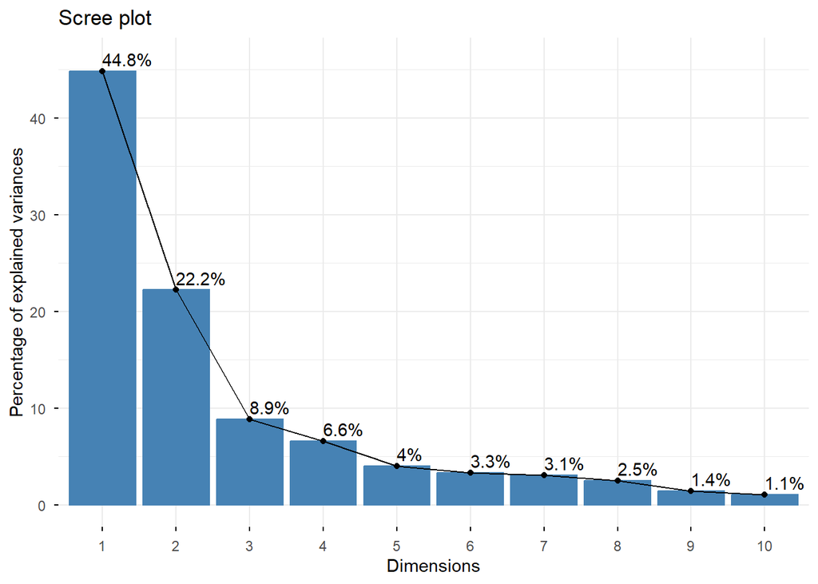

- Pour nos analyses ultérieures, nous retiendrons les **3 premières composantes principales**, qui expliquent ensemble 75,9% de la variance totale.
- Chacune de ces composantes possède une valeur propre supérieure à 1, ce qui signifie qu’elle explique une part de variance supérieure à celle d’une variable d’origine.
- La méthode du coude (critère de Kaiser), appliquée sur le screeplot des valeurs propres, suggère également que les 3 premières composantes suffisent pour expliquer l’essentiel de l’information contenue dans les données.

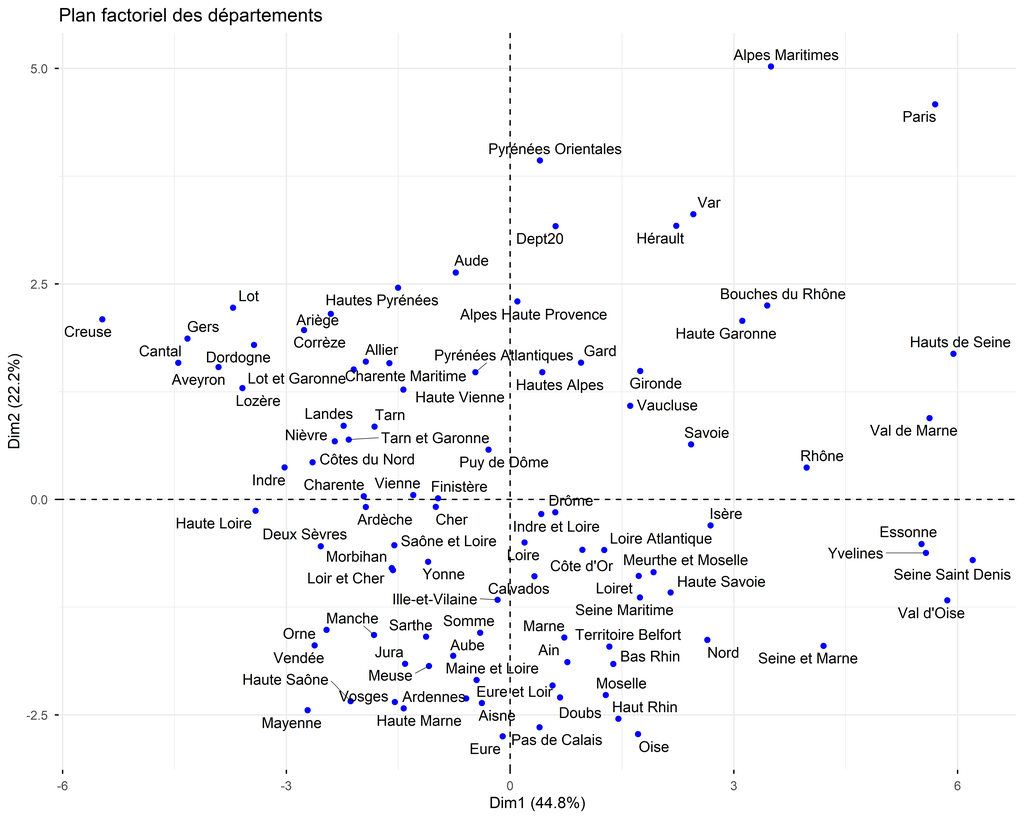

En analysant le plan factoriel des individus, on peut dire que:

- Les départements comme `Gers`, `Dordogne`, `Cantal`, `Lot` et `Aveyron` sont très proches et donc, ils ont des profils socio-économiques similaires.
- De même, d’autres départements comme `Essonne`, `Yvelines`, `Seine Saint Denis` et `Val d'Oise` ont aussi des profils socio-économiques similaires.
- Par ailleurs, les départements `Paris` et `Alpes Maritimes` présentent un profil socio-économique atypique par rapport aux autres départements, le reste formant un nuage relativement rond.

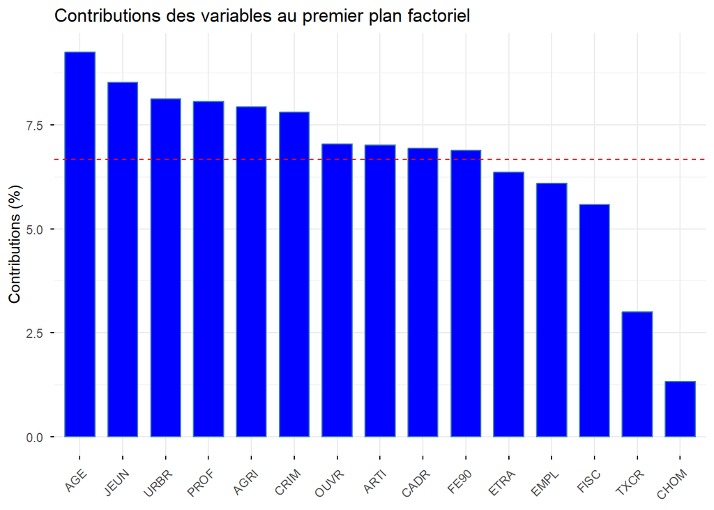

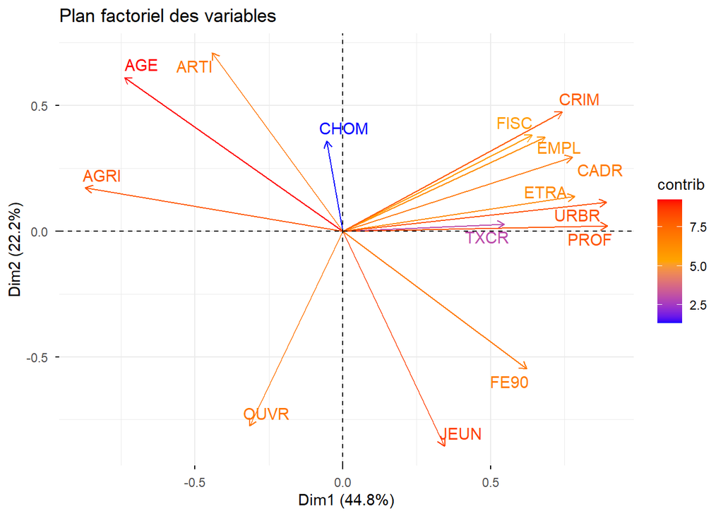

On peut vite remarquer que:

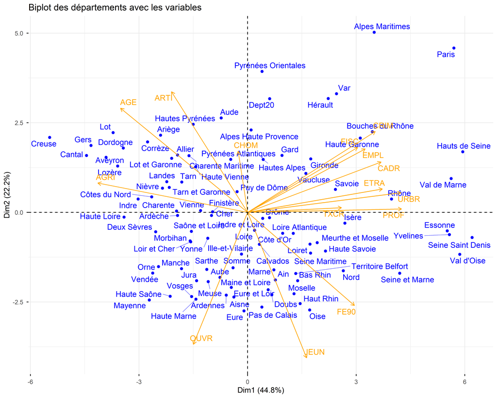

- Comme nous l’avions souligné précédemment, les départements tels que `Haut de Seine`, `Val de Marne`, `Bouche du Rhone`, `Rhone` et `Savoie` et `Isère`, qui présentent un taux élevé d’urbanisation, tendent également à présenter des taux élevés d’emploi, de criminalité et de fiscalité locale ainsi que de croissance démographique plus ou moins marquée. Ces départements se distinguent ainsi par un profil socio-économique plus marqué en termes de population active qualifiée, urbanisation, fiscalité et criminalité.
- Ces départements présentent aussi des parts élevés d’employés, de cadres supérieurs et d’étrangers, ces derniers étant souvent attirés par des opportunités d’emploi ou le tourisme.
- D’autres départements, comme `Pyrénées Atlantiques`, `Alpes Hautes Provences`, `Aude` et `Hautes Alpes`, seraient caractérisés par un fort taux de chômage.
- Et, par ailleurs, d’autres comme `Marne`, `Doubs`, `Pas de Calais` et `Ain` sont caractérisés par une part élevée de jeunes.

En gros, l’axe 1 oppose les départements les plus urbanisés aux départements les plus ruraux tandis que l’axe 2 oppose les départements majoritairement jeunes des départements majoritairement vieux.

On pourrait même dire que l’axe 1 oppose les départements dont l’économie est fortement influencée par le secteur primaire de ceux dont l’économie est surtout marquée par les secteurs tertiaires et quaternaires.

7. Maintenant que nous avons réalisé une ACP sur nos données et choisi de retenir les 3 premières composantes principales, procédons à une **Classification Ascendante Hiérarchique** afin de regrouper les départements présentant des profils socio-économiques similaires:

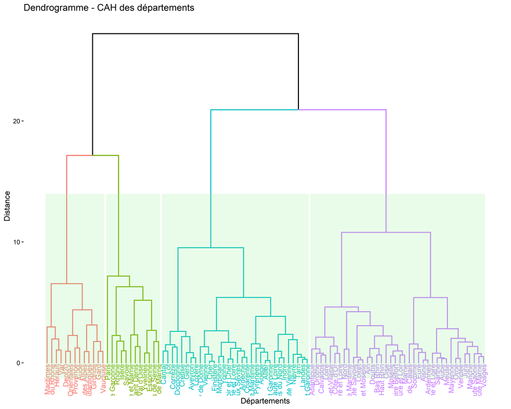

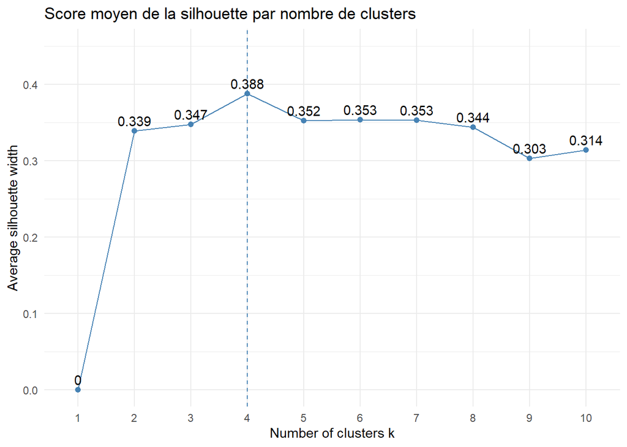

- Ici, pour $k = 4$ clusters, le score est maximal mais reste faible.
- Nous essaierons quand même avec 4 clusters.
9. Réalisons la classification K-means avec **4 clusters** et visualisons les clusters sur le premier plan factoriel:

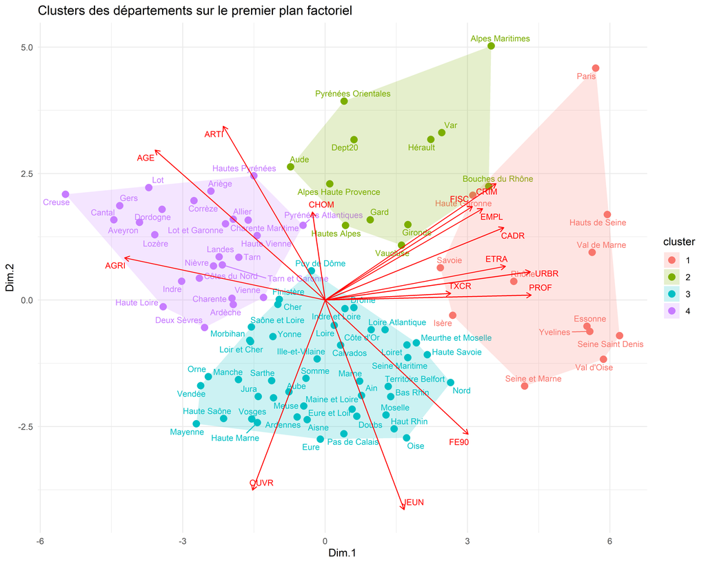

Nous pouvons observer globalement que:

- Les polygones convexes délimitent correctement les 4 groupes, avec un chevauchement minimal.

Et si on interprétait les classes:

- La classe `rouge` comprend des départements comme `Paris`, `Rhône`, `Isère`, `Savoie`, `Val de Marne` et `Hauts de Seine` et ils sont tous caractérisés par des taux élevés d’urbanisation, d’emploi, de criminalité et de fiscalité locale ainsi que de croissance démographique plus ou moins marquée. Ce sont les départements les **plus urbanisés** et les plus riches en cadres et employés qualifiés.
- La classe `verte` comprend des départements avec des profils **plutôt mixtes** puisque certains comme `Aude`, `Hautes Alpes` sont caractérisés par un fort taux de chômage alors que d’autres comme `Bouches du Rhône`, `Vaucluse` ont des taux d’emplois et de fiscalité plutôt élevés. Tous ces départements se situeraient au sud de la France et auraient une économie fortement marquée par le tourisme. Soulignons la présence à la fois de grandes métropoles ou pôles urbains tels que `Marseille` (Bouches du Rhône), `Montpellier` (Hérault), `Bordeaux` (Gironde) et de zones rurales ou montagneuses à proximité. C’est exactement ce que reflète leur position intermédiaire entre les départements les plus urbanisés et les départements les plus ruraux.
- La classe `violet`, **la plus homogène**, comprend surtout les départements les plus ruraux comme `Ariège`, `Hautes Pyrénées`, `Lozère`, `Corrèze` et `Aveyron`. En termes de population, les habitants sont pour la plupart des vieux. Et ceci explique aussi que leurs parts d’artisans et d’agriculteurs soient les plus élevées. Par ailleurs, on dénote aussi un taux de chômage assez élevé dans ces départements.
- Enfin, nous avons la classe `bleue` avec des départements comme `Pas de Calais`, `Oise`, `Haut Rhin`, `Haute Marne`, `Sarthe` ayant des populations **majoritairement jeunes** à l’opposé de la classe `violet`. Du fait de leur jeunesse, leur taux de fécondité est le plus élevé. Aussi, ces département sont caractérisés par une part d’ouvriers grande ou modérée pour certains.

Dans l’ensemble, cette classification s’avère pertinente et très informative.

La classe `verte` demeure la plus délicate à interpréter en raison de son hétérogénéité, mais celle-ci s’explique par la diversité économique propre aux départements du sud de la France.

10. On pourrait essayer d’explorer une autre méthode: celle de l’**Indice de Calinski-Harabasz** pour déterminer le nombre optimal de clusters et la qualité de la classification:

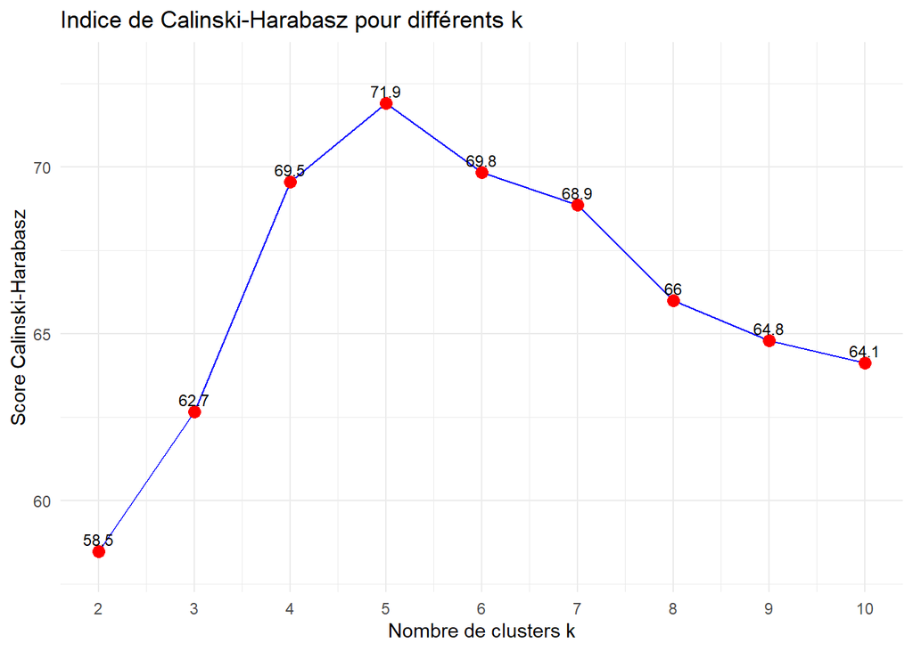

- L’indice de Calinski-Harabasz nous suggère une meilleure classification pour un nombre optimal $k = 5$ clusters, où le score est maximal et vaut `71.9`.
- Nous allons donc essayer avec 5 clusters.
11. Réalisons la classification K-means avec **5 clusters** et visualisons les clusters sur le premier plan factoriel:

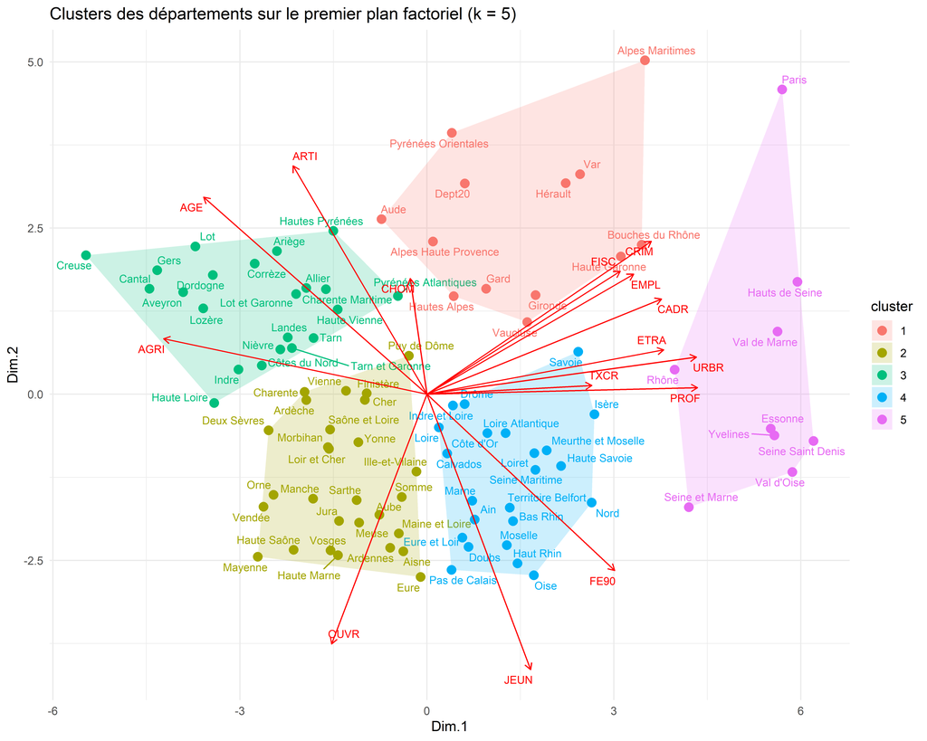

Par rapport à la classification précédente, plusieurs changements sont notables:

- Cinq classes sont identifiées, ce qui introduit un groupe supplémentaire par rapport à la solution précédente.
- Les interprétations restent globalement les mêmes pour les classes d’avant. Par contre, la nouvelle classe `violet` devient encore plus atypique du fait de éloignement de ces départements par rapport aux autres.
- La classe `bleue` d’avant a été scindée en 2 petites classes: une classe `jaune` et une nouvelle classe `bleue.`
- La nouvelle classe `jaune` regrouperait des départements fortement caractérises par une économie industrielle entretenue par une part élevée d’ouvriers.
- Tandis que la nouvelle classe `bleue` conserve l’ancien profil de départements majoritairement jeunes et plus ou moins industriels.